# Home submission (Week-12)

Divya Reddy

2025-11-19

## Part-1 Data Exploration

```r
heart <- read.csv("heart_attack_prediction_dataset.csv")
head(heart)
```

```
##   Patient.ID Age    Sex Cholesterol Blood.Pressure Heart.Rate Diabetes
## 1    BMW7812  67   Male         208         158/88         72        0
## 2    CZE1114  21   Male         389         165/93         98        1
## 3    BNI9906  21 Female         324         174/99         72        1
## 4    JLN3497  84   Male         383        163/100         73        1
## 5    GFO8847  66   Male         318          91/88         93        1
## 6    ZOO7941  54 Female         297         172/86         48        1
##   Family.History Smoking Obesity Alcohol.Consumption Exercise.Hours.Per.Week
## 1              0       1       0                   0                4.168189
## 2              1       1       1                   1                1.813242
## 3              0       0       0                   0                2.078353
## 4              1       1       0                   1                9.828130
## 5              1       1       1                   0                5.804299
## 6              1       1       0                   1                0.625008
##        Diet Previous.Heart.Problems Medication.Use Stress.Level
```

[output cut: 27 more lines]

```r
str(heart)
```

```
## 'data.frame':    8763 obs. of  26 variables:
##  $ Patient.ID                     : chr  "BMW7812" "CZE1114" "BNI9906" "JLN3497" ...
##  $ Age                            : int  67 21 21 84 66 54 90 84 20 43 ...
##  $ Sex                            : chr  "Male" "Male" "Female" "Male" ...
##  $ Cholesterol                    : int  208 389 324 383 318 297 358 220 145 248 ...
##  $ Blood.Pressure                 : chr  "158/88" "165/93" "174/99" "163/100" ...
##  $ Heart.Rate                     : int  72 98 72 73 93 48 84 107 68 55 ...
##  $ Diabetes                       : int  0 1 1 1 1 1 0 0 1 0 ...
##  $ Family.History                 : int  0 1 0 1 1 1 0 0 0 1 ...
##  $ Smoking                        : int  1 1 0 1 1 1 1 1 1 1 ...
##  $ Obesity                        : int  0 1 0 0 1 0 0 1 1 1 ...
##  $ Alcohol.Consumption            : int  0 1 0 1 0 1 1 1 0 1 ...
##  $ Exercise.Hours.Per.Week        : num  4.17 1.81 2.08 9.83 5.8 ...
##  $ Diet                           : chr  "Average" "Unhealthy" "Healthy" "Average" ...
##  $ Previous.Heart.Problems        : int  0 1 1 1 1 1 0 0 0 0 ...
##  $ Medication.Use                 : int  0 0 1 0 0 1 0 1 0 0 ...
##  $ Stress.Level                   : int  9 1 9 9 6 2 7 4 5 4 ...
##  $ Sedentary.Hours.Per.Day        : num  6.62 4.96 9.46 7.65 1.51 ...
##  $ Income                         : int  261404 285768 235282 125640 160555 241339 190450 122093 25086 209703 ...
##  $ BMI                            : num  31.3 27.2 28.2 36.5 21.8 ...
##  $ Triglycerides                  : int  286 235 587 378 231 795 284 370 790 232 ...
##  $ Physical.Activity.Days.Per.Week: int  0 1 4 3 1 5 4 6 7 7 ...
##  $ Sleep.Hours.Per.Day            : int  6 7 4 4 5 10 10 7 4 7 ...
##  $ Country                        : chr  "Argentina" "Canada" "France" "Canada" ...
##  $ Continent                      : chr  "South America" "North America" "Europe" "North America" ...
##  $ Hemisphere                     : chr  "Southern Hemisphere" "Northern Hemisphere" "Northern Hemisphere" "Northern Hemisphere" ...
##  $ Heart.Attack.Risk              : int  0 0 0 0 0 1 1 1 0 0 ...
```

```r
summary(heart)
```

```
##   Patient.ID             Age            Sex             Cholesterol
##  Length:8763        Min.   :18.00   Length:8763        Min.   :120.0
##  Class :character   1st Qu.:35.00   Class :character   1st Qu.:192.0
##  Mode  :character   Median :54.00   Mode  :character   Median :259.0
##                     Mean   :53.71                      Mean   :259.9
##                     3rd Qu.:72.00                      3rd Qu.:330.0
##                     Max.   :90.00                      Max.   :400.0
##  Blood.Pressure       Heart.Rate        Diabetes      Family.History
##  Length:8763        Min.   : 40.00   Min.   :0.0000   Min.   :0.000
##  Class :character   1st Qu.: 57.00   1st Qu.:0.0000   1st Qu.:0.000
##  Mode  :character   Median : 75.00   Median :1.0000   Median :0.000
##                     Mean   : 75.02   Mean   :0.6523   Mean   :0.493
##                     3rd Qu.: 93.00   3rd Qu.:1.0000   3rd Qu.:1.000
##                     Max.   :110.00   Max.   :1.0000   Max.   :1.000
##     Smoking          Obesity       Alcohol.Consumption Exercise.Hours.Per.Week
##  Min.   :0.0000   Min.   :0.0000   Min.   :0.0000      Min.   : 0.002442
##  1st Qu.:1.0000   1st Qu.:0.0000   1st Qu.:0.0000      1st Qu.: 4.981579
##  Median :1.0000   Median :1.0000   Median :1.0000      Median :10.069559
##  Mean   :0.8968   Mean   :0.5014   Mean   :0.5981      Mean   :10.014284
##  3rd Qu.:1.0000   3rd Qu.:1.0000   3rd Qu.:1.0000      3rd Qu.:15.050018
##  Max.   :1.0000   Max.   :1.0000   Max.   :1.0000      Max.   :19.998709
##      Diet           Previous.Heart.Problems Medication.Use    Stress.Level
##  Length:8763        Min.   :0.0000          Min.   :0.0000   Min.   : 1.00
##  Class :character   1st Qu.:0.0000          1st Qu.:0.0000   1st Qu.: 3.00
##  Mode  :character   Median :0.0000          Median :0.0000   Median : 5.00
##                     Mean   :0.4958          Mean   :0.4983   Mean   : 5.47
##                     3rd Qu.:1.0000          3rd Qu.:1.0000   3rd Qu.: 8.00
##                     Max.   :1.0000          Max.   :1.0000   Max.   :10.00
##  Sedentary.Hours.Per.Day     Income            BMI        Triglycerides
##  Min.   : 0.001263       Min.   : 20062   Min.   :18.00   Min.   : 30.0
##  1st Qu.: 2.998794       1st Qu.: 88310   1st Qu.:23.42   1st Qu.:225.5
##  Median : 5.933622       Median :157866   Median :28.77   Median :417.0
##  Mean   : 5.993690       Mean   :158263   Mean   :28.89   Mean   :417.7
##  3rd Qu.: 9.019125       3rd Qu.:227749   3rd Qu.:34.32   3rd Qu.:612.0
##  Max.   :11.999313       Max.   :299954   Max.   :40.00   Max.   :800.0
##  Physical.Activity.Days.Per.Week Sleep.Hours.Per.Day   Country
##  Min.   :0.00                    Min.   : 4.000      Length:8763
##  1st Qu.:2.00                    1st Qu.: 5.000      Class :character
##  Median :3.00                    Median : 7.000      Mode  :character
##  Mean   :3.49                    Mean   : 7.024
##  3rd Qu.:5.00                    3rd Qu.: 9.000
##  Max.   :7.00                    Max.   :10.000
##   Continent          Hemisphere        Heart.Attack.Risk
##  Length:8763        Length:8763        Min.   :0.0000
##  Class :character   Class :character   1st Qu.:0.0000
##  Mode  :character   Mode  :character   Median :0.0000
##                                        Mean   :0.3582
##                                        3rd Qu.:1.0000
##                                        Max.   :1.0000
```

I chose the Heart Attack Prediction dataset because, unlike the other two datasets selected by my group, it is structured in a way that is appropriate for multiple regression analysis. The COVID-19 datasets were mainly time-series based, contained daily or cumulative counts, and required advanced preprocessing, which made them unsuitable for the type of independent, continuous predictors needed for this assignment. In contrast, the Heart Attack dataset provides clean individual-level observations with many continuous variables such as age, cholesterol, BMI, income, triglycerides, sleep hours, and sedentary hours that can be directly used in a regression model. This dataset is easy to load, properly formatted, and offers a clear real-world health context, making it the most suitable choice among the three for conducting multiple regression and interpreting the results effectively.

```r
# Count total missing values
sum(is.na(heart))
```

```
## [1] 0
```

```r
# Check missing values column-wise
colSums(is.na(heart))
```

```
##                      Patient.ID                             Age
##                               0                               0
##                             Sex                     Cholesterol
##                               0                               0
##                  Blood.Pressure                      Heart.Rate
##                               0                               0
##                        Diabetes                  Family.History
##                               0                               0
##                         Smoking                         Obesity
##                               0                               0
##             Alcohol.Consumption         Exercise.Hours.Per.Week
##                               0                               0
##                            Diet         Previous.Heart.Problems
##                               0                               0
##                  Medication.Use                    Stress.Level
##                               0                               0
##         Sedentary.Hours.Per.Day                          Income
##                               0                               0
##                             BMI                   Triglycerides
##                               0                               0
## Physical.Activity.Days.Per.Week             Sleep.Hours.Per.Day
##                               0                               0
##                         Country                       Continent
##                               0                               0
##                      Hemisphere               Heart.Attack.Risk
##                               0                               0
```

```r
# The dataset was checked for missing values using both total and column-wise summaries in R. The results showed that there were no missing values in any of the 26 variables. Since the dataset is fully complete, no imputation or data cleaning was required at this stage. The dataset is ready to be used directly for multiple regression analysis without any modifications related to missing data.
```

**Variable selection:**

- Dependent Variable:

Heart.Attack.Risk

Reason: This variable represents whether an individual is at risk of a heart attack (0 = No risk, 1 = Risk). It is the main outcome the dataset is designed to study.

- Independent Variable:
- Age

Reason: Age is one of the strongest predictors of heart disease because cardiovascular risk increases significantly as people get older.

- Cholesterol

Reason: High cholesterol contributes to plaque buildup in arteries and is medically recognized as a major risk factor for heart attacks.

**Descriptive statistics**

```r
# Select variables
vars <- heart[, c("Heart.Attack.Risk", "Age", "Cholesterol")]

# Calculate summary statistics
summary(vars)
```

```
##  Heart.Attack.Risk      Age         Cholesterol
##  Min.   :0.0000    Min.   :18.00   Min.   :120.0
##  1st Qu.:0.0000    1st Qu.:35.00   1st Qu.:192.0
##  Median :0.0000    Median :54.00   Median :259.0
##  Mean   :0.3582    Mean   :53.71   Mean   :259.9
##  3rd Qu.:1.0000    3rd Qu.:72.00   3rd Qu.:330.0
##  Max.   :1.0000    Max.   :90.00   Max.   :400.0
```

```r
# Calculate standard deviation
sapply(vars, sd)
```

```
## Heart.Attack.Risk               Age       Cholesterol
##         0.4795018        21.2495088        80.8632761
```

```r
# Interpretation: The dependent variable Heart.Attack.Risk ranges from 0 to 1, with a mean of 0.358, indicating that around 36% of the individuals in the dataset are at risk of a heart attack. Age ranges from 18 to 90 years, with a mean of 53.71 and a median of 54, showing that the sample includes both younger and older adults. Cholesterol values range from 120 to 400 mg/dL, with a mean of 259.9 and a median of 259, which suggests that many individuals have moderately high cholesterol levels. The standard deviations for Age (21.25) and Cholesterol (80.86) indicate substantial variability across the sample. These descriptive statistics confirm that the variables show enough variation to be suitable for regression analysis.
```

## Part 2: Model building

**Correlation Analysis:**

```r
indep_vars <- heart[, c("Age", "Cholesterol")]

# Correlation matrix
cor_matrix <- cor(indep_vars)
cor_matrix
```

```
##                      Age  Cholesterol
## Age          1.000000000 -0.009107011
## Cholesterol -0.009107011  1.000000000
```

```r
# Interpretation: A correlation analysis was conducted on the two independent variables, Age and Cholesterol, to check for multicollinearity before building the regression model. The correlation coefficient between Age and Cholesterol was approximately –0.009, which is extremely close to zero. Since this value is far below the multicollinearity threshold of 0.7, there is no evidence of a strong linear relationship between the predictors. Therefore, multicollinearity is not a concern, and both variables can be safely included in the regression model.
```

**Fit a Multiple Regression Model:**

```r
# Fit the multiple regression model
model <- lm(Heart.Attack.Risk ~ Age + Cholesterol, data = heart)

# View model summary
summary(model)
```

```
##
## Call:
## lm(formula = Heart.Attack.Risk ~ Age + Cholesterol, data = heart)
##
## Residuals:
##     Min      1Q  Median      3Q     Max
## -0.3794 -0.3616 -0.3490  0.6351  0.6630
##
## Coefficients:
##              Estimate Std. Error t value Pr(>|t|)
## (Intercept) 3.203e-01  2.165e-02  14.796   <2e-16 ***
## Age         1.485e-04  2.411e-04   0.616   0.5379
## Cholesterol 1.150e-04  6.335e-05   1.816   0.0694 .
## ---
## Signif. codes:  0 '***' 0.001 '**' 0.01 '*' 0.05 '.' 0.1 ' ' 1
##
## Residual standard error: 0.4795 on 8760 degrees of freedom
## Multiple R-squared:  0.0004173,  Adjusted R-squared:  0.0001891
## F-statistic: 1.829 on 2 and 8760 DF,  p-value: 0.1607
```

**Interpret the Coefficients:**

- Age:

The coefficient for Age is 0.000148, which means that for every additional year of age, the predicted heart attack risk increases by only 0.000148 units, holding cholesterol constant. This effect is extremely small and not statistically significant.

- Cholesterol:

The coefficient for Cholesterol is 0.000115, meaning that for every 1 mg/dL increase in cholesterol, the predicted heart attack risk increases by 0.000115 units, holding age constant. This effect is also very small and only marginally close to significance.

- Intercept:

The intercept of 0.3203 represents the baseline predicted heart attack risk when both age and cholesterol are zero, but this value mainly serves as a mathematical starting point and has no practical meaning since age and cholesterol cannot realistically be zero.

## Part 3: Model evaluation

**Model fit**

The model produced an R-squared value of 0.000417 and an Adjusted R-squared value of 0.000189. These values are extremely close to zero, meaning the model explains almost none of the variation in heart attack risk. This indicates a very poor fit, as Age and Cholesterol do not meaningfully predict the outcome in this dataset. Because both R-squared measures are essentially zero, the model does not provide useful predictive power and does not capture the factors that influence heart attack risk.

**Statistical Significance:**

The p-values for the predictors were examined at the 0.05 significance level. Age had a p-value of 0.5379, and Cholesterol had a p-value of 0.0694. Since both p-values are greater than 0.05, neither Age nor Cholesterol is statistically significant in predicting Heart.Attack.Risk. This means that, based on this dataset, there is no strong evidence that changes in age or cholesterol levels are associated with changes in heart attack risk when included in this simple multiple regression model.

**Generate Diagnostic Plots:**

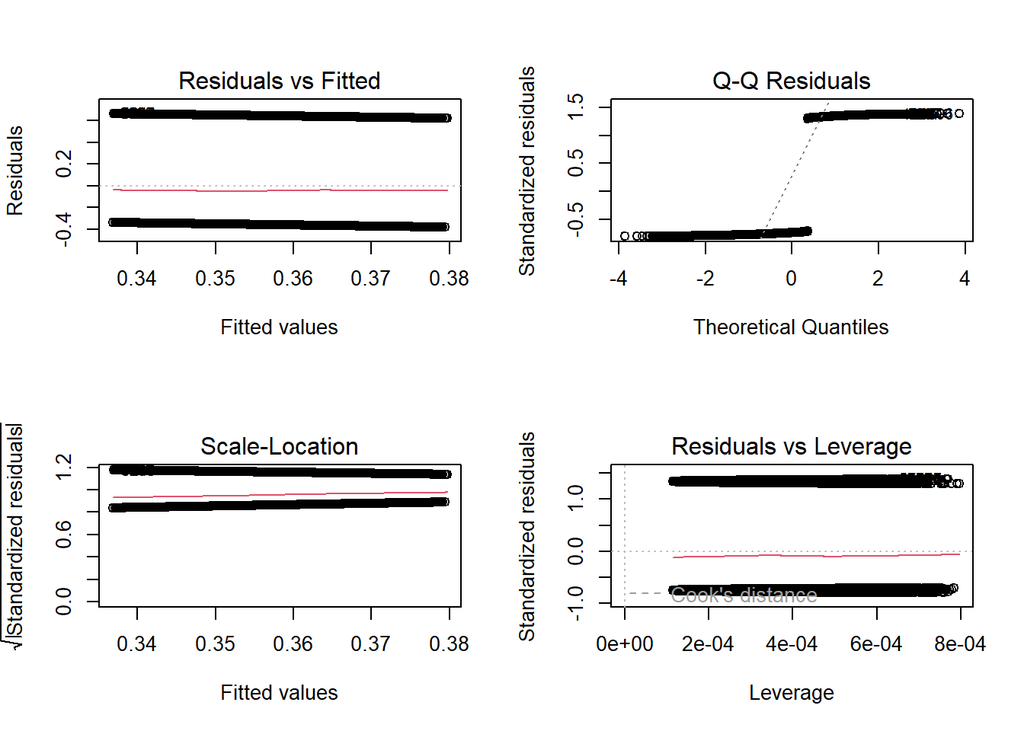

```r
# Regression model
model <- lm(Heart.Attack.Risk ~ Age + Cholesterol, data = heart)

# Diagnostic plots
par(mfrow = c(2,2))
plot(model)
```

- Errors Normally Distributed:

The Q-Q plot shows strong deviations from the diagonal line, especially at the tails. The residuals are not normally distributed, again due to the binary nature of the response variable. This violates the normality assumption of linear regression.

- Homoscedasticity:

The Scale-Location plot shows uneven spread of the residuals, forming horizontal bands. This indicates heteroscedasticity, meaning the variance of errors is not constant across fitted values. This also violates a key assumption.

- Multicollinearity:

There is no issue with multicollinearity. Earlier correlation analysis showed Age and Cholesterol had a correlation of only –0.009, far below the 0.7 threshold.

- Outliers:

The Residuals vs Leverage plot shows no extreme leverage points or Cook’s distance values. While the residuals cluster due to the binary outcome, there are no influential outliers that would threaten model stability.

## Part 4: Report findings

**Summary of Results:**

The regression model found very weak positive relationships between Age, Cholesterol, and Heart.Attack.Risk, but neither predictor was statistically significant. The R-squared value was close to zero, indicating almost no explanatory power. Diagnostic checks showed violations of linear regression assumptions due to the binary outcome, though no multicollinearity or major outliers were present.

**Conclusion:**

The analysis shows that Age and Cholesterol do not meaningfully predict heart attack risk in this dataset. Because the dependent variable is binary, linear regression is not an appropriate modeling method. A logistic regression model with additional health-related predictors would likely provide more accurate and meaningful results.